# STIN100 Datasett 3: Når får barn en tarmflora som ligner på den vi ser hos voksne?

## 2.5 beregne gjenomsnittlig antall taxa som finnes i observasjons-gruppene

Videre ønsker vi å regne ut gjennomsnittet for mor og barn ved ulike tidspunkter for å se hvordan bakteriefloraen er forskjellig hos mor og barn og hvordan den endrer seg over tid.

Første steget vår blir å forekle data vå litt. Vi slår sammen kolonne 4,5, og 6. Vi fordeler de på kolonnene Taxa og AntallBakterier. Dermed har vi samlet taxon-variablene våres i to nye variabler. Dette vil gjøre videre undersøkelser enklere.

```r
leke_data %>%
  gather(Taxa, AntallBakterier, -(1:3))
```

```
## # A tibble: 54 x 5
##    MotherChildPairID MotherChild Timepoint Taxa            AntallBakterier
##                <dbl> <fct>       <fct>     <chr>                     <dbl>
##  1             23254 mother      Pregnancy Methanobreviba~              49
##  2             23474 mother      Pregnancy Methanobreviba~               9
##  3             22303 mother      Pregnancy Methanobreviba~               0
##  4             21407 mother      3months   Methanobreviba~             235
##  5             23254 mother      3months   Methanobreviba~              59
##  6             21831 mother      3months   Methanobreviba~               0
##  7             22622 child       10days    Methanobreviba~               0
##  8             22596 child       10days    Methanobreviba~               0
##  9             22751 child       10days    Methanobreviba~               0
## 10             20933 child       3months   Methanobreviba~               0
## # ... with 44 more rows
```

```r
GjennomsnittligAntallTaxa.lekedata <- leke_data %>%
  gather(Taxa, AntallBakterier, -(1:3)) %>%
  group_by(MotherChildPairID, MotherChild, Timepoint) %>%
  summarise(AntallTaxa = sum(AntallBakterier > 0)) %>%
  group_by(MotherChild, Timepoint) %>%
  summarise(GjennomsnittligAntallTaxa = mean(AntallTaxa))

GjennomsnittligAntallTaxa.lekedata
```

```
## # A tibble: 6 x 3
## # Groups:   MotherChild [?]
##   MotherChild Timepoint GjennomsnittligAntallTaxa
##   <fct>       <fct>                         <dbl>
## 1 mother      Pregnancy                     1.33
## 2 mother      3months                       1
## 3 child       10days                        0
## 4 child       3months                       0.667
## 5 child       1year                         0.333
## 6 child       2years                        0.667
```

## 2.5.1

Nå skal vi gjøre det med hele datasette vårt. Fra det vi får som output kan vi se at antall ulike arter i barn utvider seg over tid og at det er vesentlig mere bakterier i mor enn bar.

```r
GjennomsnittligAntallTaxa <- data %>%
  gather(Taxa, AntallBakterier, -(1:3)) %>%
  group_by(MotherChildPairID, MotherChild, Timepoint) %>%
  summarise(AntallTaxa = sum(AntallBakterier > 0)) %>%
  group_by(MotherChild, Timepoint) %>%
  summarise(GjennomsnittligAntallTaxa = mean(AntallTaxa))

GjennomsnittligAntallTaxa
```

```
## # A tibble: 6 x 3
## # Groups:   MotherChild [?]
##   MotherChild Timepoint GjennomsnittligAntallTaxa
##   <fct>       <fct>                         <dbl>
## 1 mother      Pregnancy                     130.
## 2 mother      3months                       131.
## 3 child       10days                         22.4
## 4 child       3months                        26.4
## 5 child       1year                          58.6
## 6 child       2years                         87.6
```

## 2.5.2

Etter å ha plottet dataen i et boksplott ser vi nå at antall ulike typer bakterier for et indevid varierer mer med alderen.

Figur 1:

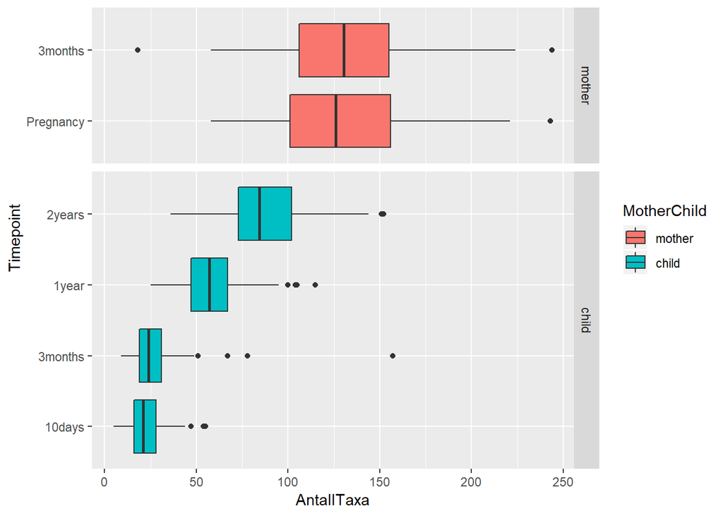

```r
library(ggplot2)

Gjennomsnitt.taksa <- data %>%
  gather(Taxa, AntallBakterier, -(1:3)) %>%
  group_by(MotherChildPairID, MotherChild, Timepoint) %>%
  summarise(AntallTaxa = sum(AntallBakterier > 0))

ggplot(Gjennomsnitt.taksa, aes(Timepoint, AntallTaxa, fill = MotherChild)) + geom_boxplot() + facet_grid(rows =  vars(Gjennomsnitt.taksa$MotherChild), scales = "free", space = "free") + coord_flip()
```

## 3.2 Hvilke taxa er mest vanlige?

Igjen for å besvare spørsmålet i overskriften ska vi først teste funksjonene vå på lekedata sette vårt.

```r
AntallIndivid <- leke_data %>%
  gather(Taxa, AntallBakterier, -(1:3)) %>%
  group_by(Taxa) %>%
  summarise(AntallIndivid = sum(AntallBakterier > 0))

AntallIndivid
```

```
## # A tibble: 3 x 2
##   Taxa               AntallIndivid
##   <chr>                      <int>
## 1 Clostridiales                  2
## 2 Dialister                      4
## 3 Methanobrevibacter             6
```

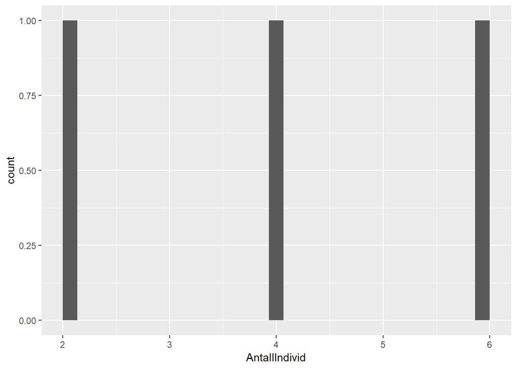

```r
leke_data %>%
  gather(Taxa, AntallBakterier, -(1:3)) %>%
  group_by(Taxa) %>%
  summarise(AntallIndivid = sum(AntallBakterier > 0)) %>%
  ggplot(aes(AntallIndivid)) + geom_histogram()
```

## 3.2.1

Nå som koden funker skal vi bruke det på hele datasette

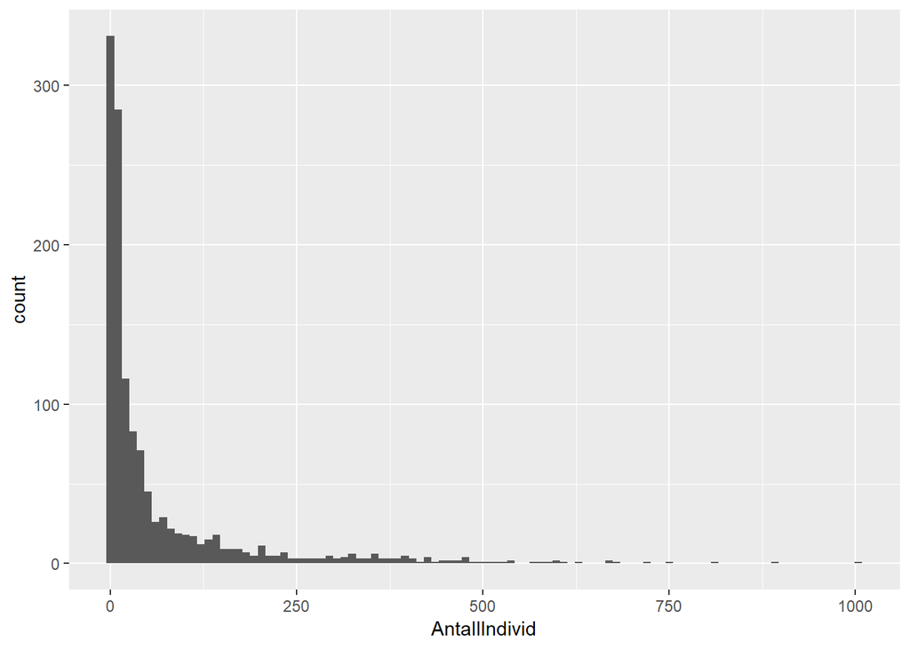

```r
data %>%
  gather(Taxa, AntallBakterier, -(1:3)) %>%
  group_by(Taxa) %>%
  summarise(AntallIndivid = sum(AntallBakterier > 0)) %>%
  ggplot(aes(AntallIndivid)) + geom_histogram(bins=100)
```

Faecalibacterium er en rekke bakterier som finnes i store mengder i det menneskelige fordøyelsessystemet. Proteinproduksjonen til bakterien har blitt koblet til anti-innflamatoriske effekter i mageregionen

Bifidobacterium er rekke bakterier som er funnet i munn og svelg hos mennesker. Bakteriene har blitt brukt som en probiotisk faktor i etterbehandlingen av mennesker som har hatt magesår. Bakterien fermenterer melk, og gjør dermed ph-nivået surere. Dette hjelper mot patogener som ellers vil kunne angripe fordøyelsessystemet.

Lachnospiraceae er en familie bakterier som finnes i menneskets magemikrobiota. Bakterien kan hende at beskytter mot tarmkreft, uten at dette er bevist. Det er bevist at bakterien kan gi bakteriefrie mus diabetes.

## 3.2.2 Hvilke taxa finnes i mer enn 250 individer?

```r
taxa_250 <- data %>%
  gather(Taxa, AntallBakterier, -(1:3)) %>%
  group_by(Taxa) %>%
  summarise(AntallIndivid = sum(AntallBakterier > 0)) %>%
  filter(AntallIndivid > 250) %>%
  arrange(desc(AntallIndivid))

taxa_250
```

```
## # A tibble: 97 x 2
##    Taxa                 AntallIndivid
##    <chr>                        <int>
##  1 Bifidobacterium               1004
##  2 Streptococcus                  893
##  3 Streptococcus.2                816
##  4 Bifidobacterium.1              755
##  5 Bifidobacterium.2              717
##  6 Lachnospiraceae.1              676
##  7 Faecalibacterium               667
##  8 Streptococcus.3                665
##  9 Enterobacteriaceae.2           627
## 10 Bifidobacterium.4              607
## # ... with 87 more rows
```

## 3.2.2 Lag et histogram for hver observasjons-gruppe.

Merk at at noen av historgrammene er tomme. Dette har å gjøre at målingene for unger ikke inkluderer tidsperioden for når moren var gravid. Videre ble mødrene testet når de var gravid og 3 månder etter fødsel.

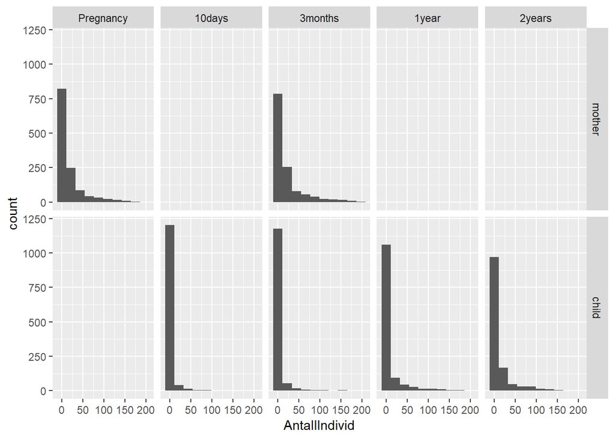

```r
data %>%
  gather(Taxa, AntallBakterier, -(1:3)) %>%
  group_by(Taxa, Timepoint, MotherChild) %>%
  summarise(AntallIndivid = sum(AntallBakterier > 0)) %>%
  ggplot(aes(AntallIndivid)) + geom_histogram(bins=10) + facet_grid(rows = vars(MotherChild), cols = vars(Timepoint))
```

3.2.3

```r
Null_individer <- data %>%
  gather(Taxa, AntallBakterier, -(1:3)) %>%
  group_by(Taxa) %>%
  summarise(AntallIndivid = sum(AntallBakterier > 0)) %>%
  filter(AntallIndivid == 0)


count(Null_individer)
```

```
## # A tibble: 1 x 1
##       n
##   <int>
## 1     6
```

```r
#Nå har vi fjernet null_individer fra tabellen data med funskjonen under
data.null <- data %>%
  select(-c(Null_individer$Taxa))
```

## 4 Kvantitative data - fra telling til multivariat analyse

## 4.1 Normalisering

```r
microCLR <- function(read.counts, n.pseudo=0){
  depths <- rowSums(read.counts)
  RC <- read.counts + n.pseudo
  RRC <- RC/rowSums(RC)

  if(n.pseudo>0){
    g <- apply(RRC, 1, function(x){mean(log2(x))})
    X <- log2(RRC) - g
  } else {
    X <- RRC
  }
  rownames(X) <- rownames(read.counts)
  colnames(X) <- colnames(read.counts)
  attr(X, "depths") <- depths

  return(X)
}

data.norm <- data.null[,-(1:3)]


data.norm <- microCLR(data.norm, n.pseudo = 1)

data.norm <- bind_cols(MotherChildPairID = data$MotherChildPairID, MotherChild = data$MotherChild, Timepoint = data$Timepoint, data.norm)
```

## 4.1.1 Plotting av alle verdiene i data.norm (Noe er feil her, finn ut hva)

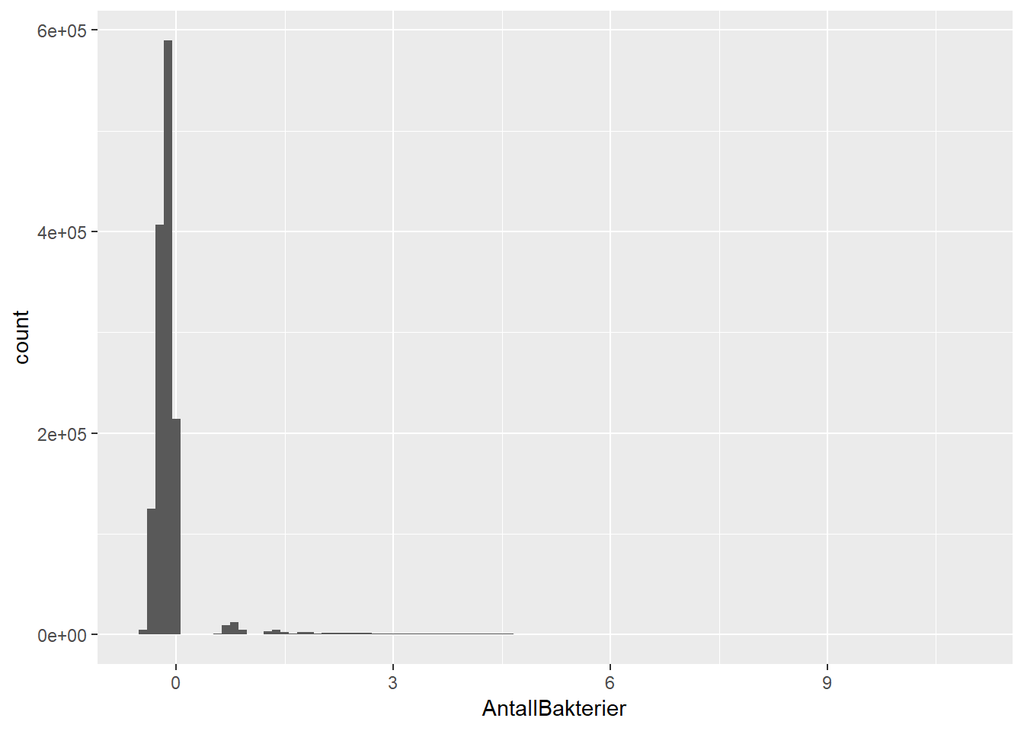

```r
data.norm %>%
  gather(Taxa, AntallBakterier, -(1:3)) %>%
  ggplot(aes(AntallBakterier)) + geom_histogram(bins=100)
```

```r
dim(data.norm)
```

```
## [1] 1124 1271
```

```r
data.norm$MotherChild <- as.factor(data$MotherChild)
data.norm$MotherChild <- factor(data.norm$MotherChild, levels = c("mother", "child"))

data.norm$Timepoint <- as.factor(data.norm$Timepoint)
data.norm$Timepoint <- factor(data.norm$Timepoint, levels = c("Pregnancy", "10days",  "3months", "1year", "2years"))
```

## 4.2 Prinsipal komponent analyse (PCA)

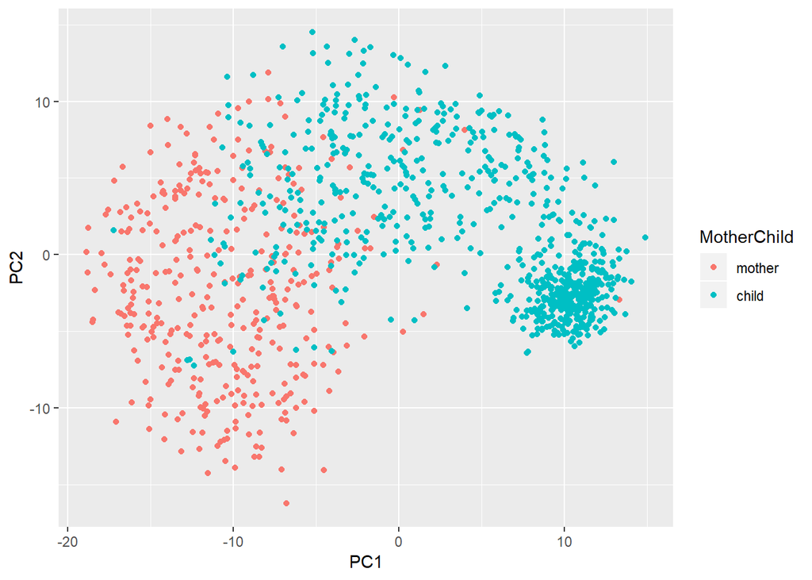

```r
pca.res <- prcomp(data.norm[,-(1:3)])
data.pca <- bind_cols(data.norm[,1:3], as.tibble(pca.res$x))

data.pca %>%
  ggplot(aes(PC1, PC2, color = MotherChild)) + geom_point()
```